# Rとは

のいず

2015年8月16日

# 散布図・回帰直線・相関係数

## 散布図と回帰直線

irisデータを使って処理を順番に見てみよう。 irisデータはあやめの顎の長さ・額の幅・花びらの長さ・花びらの幅・あやめの種類が入ったデータです。

```r
#Irisデータの読み込み
data("iris")

head(iris)
```

```
##   Sepal.Length Sepal.Width Petal.Length Petal.Width Species
## 1          5.1         3.5          1.4         0.2  setosa
## 2          4.9         3.0          1.4         0.2  setosa
## 3          4.7         3.2          1.3         0.2  setosa
## 4          4.6         3.1          1.5         0.2  setosa
## 5          5.0         3.6          1.4         0.2  setosa
## 6          5.4         3.9          1.7         0.4  setosa
```

```r
str(iris)
```

```
## 'data.frame':    150 obs. of  5 variables:
##  $ Sepal.Length: num  5.1 4.9 4.7 4.6 5 5.4 4.6 5 4.4 4.9 ...
##  $ Sepal.Width : num  3.5 3 3.2 3.1 3.6 3.9 3.4 3.4 2.9 3.1 ...
##  $ Petal.Length: num  1.4 1.4 1.3 1.5 1.4 1.7 1.4 1.5 1.4 1.5 ...
##  $ Petal.Width : num  0.2 0.2 0.2 0.2 0.2 0.4 0.3 0.2 0.2 0.1 ...
##  $ Species     : Factor w/ 3 levels "setosa","versicolor",..: 1 1 1 1 1 1 1 1 1 1 ...
```

数字をあれこれする前にまずはデータをグラフで表してみましょう。 ここではggplot2を使います。 まずは顎・花びらのそれぞれについてx軸に長さを、y軸に幅を設定して散布図を描いてみます。

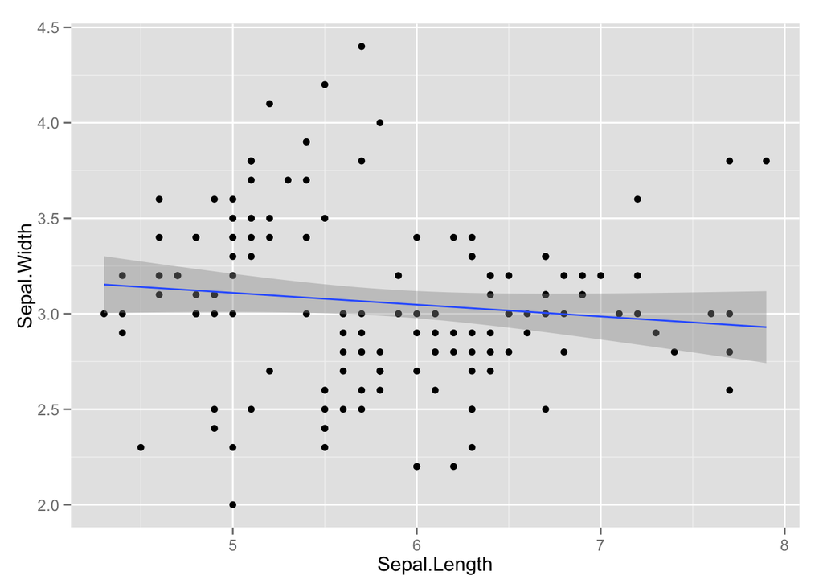

```r
#ggplot2の読み込み
library(ggplot2)

#顎の長さと幅
ggplot(iris,aes(x=Sepal.Length,y=Sepal.Width))+geom_point()+geom_smooth(method=lm)
```

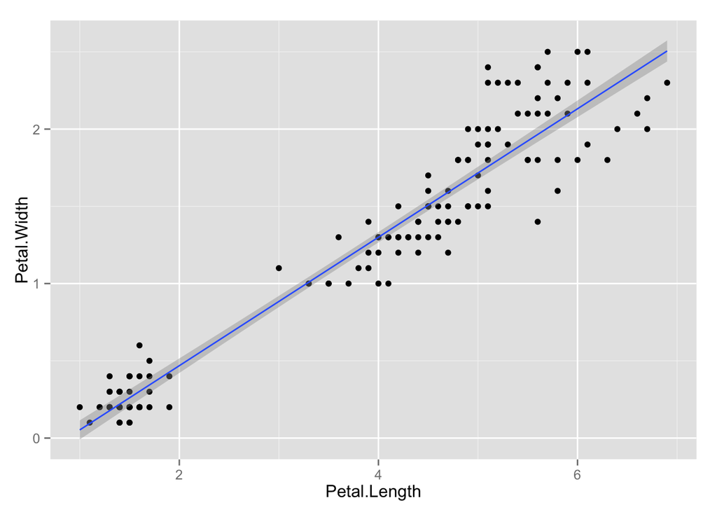

```r
#花びらの長さと幅
ggplot(iris,aes(x=Petal.Length,y=Petal.Width))+geom_point()+geom_smooth(method=lm)
```

額の長さと幅は無相関で、花びらの長さと幅には相関がありそうに見えます。 では本当にそうなのでしょうか？

次はさきほどの散布図にあやめの種類のデータを反映させて色分けしてみます。

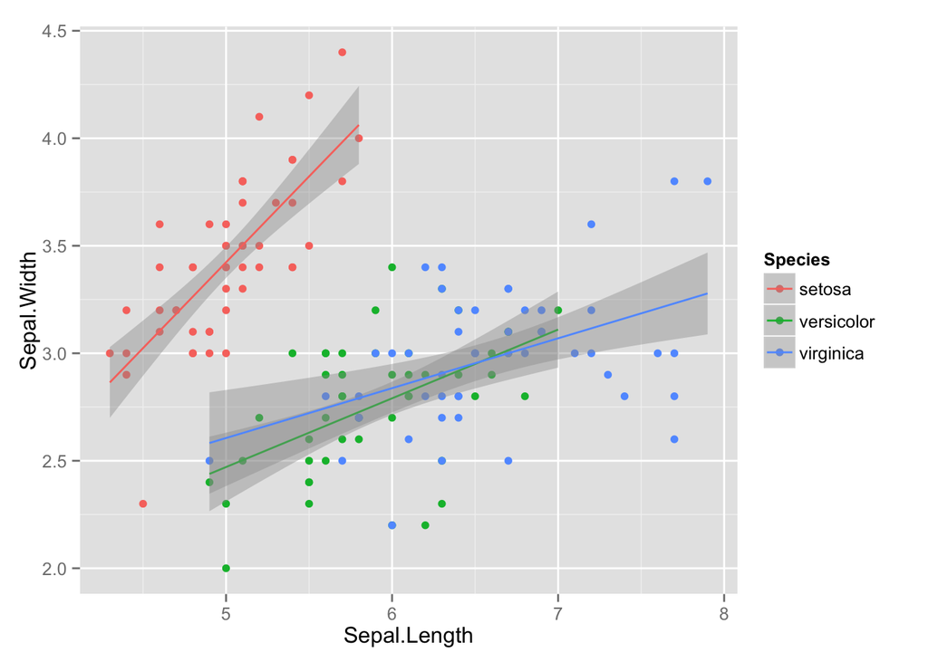

```r
#顎の長さと幅
ggplot(iris,aes(x=Sepal.Length,y=Sepal.Width,color=Species))+geom_point()+geom_smooth(method=lm)
```

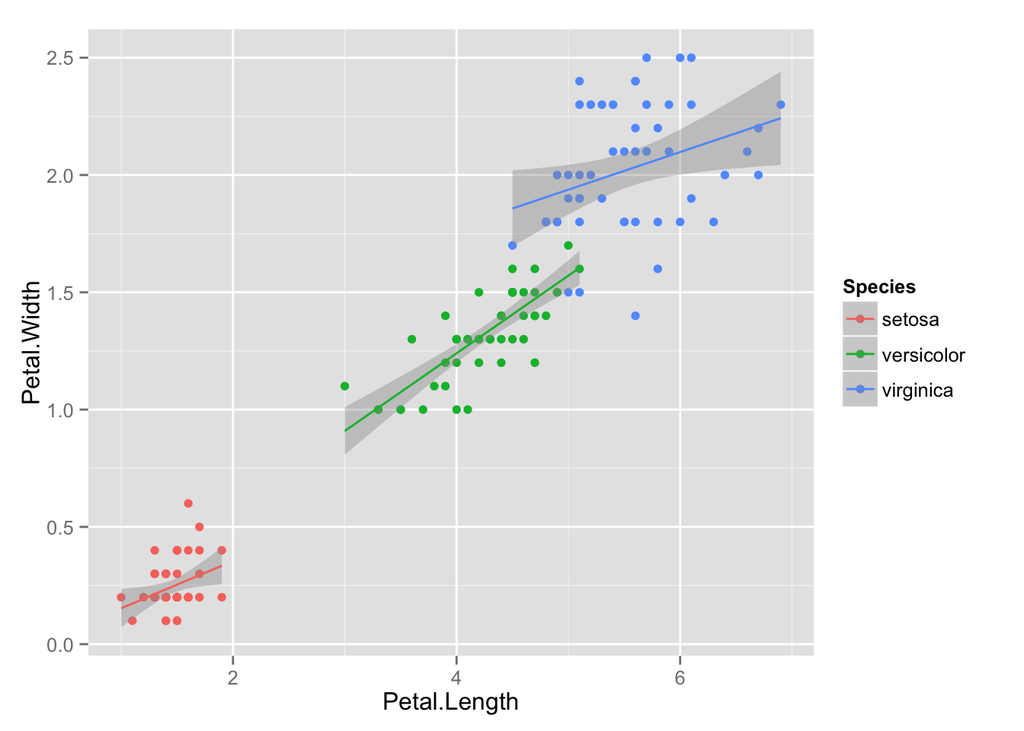

```r
#花びらの長さと幅
ggplot(iris,aes(x=Petal.Length,y=Petal.Width,color=Species))+geom_point()+geom_smooth(method=lm)
```

色分けしてみると額も花びらも種別ごとに分布が違っていることがわかります。 種類の違うあやめを一緒にして散布図にしていたため、 種類ごとの特徴が見えなくなっていたということです。

ではどこまで種類分けするべきなのでしょうか。 これは自分が分析したいのがどの程度のカテゴリ分けなのかによって違います。 さきほどの例でいうとあやめという花の全体の傾向を見たいのであれば、 種類ごとに分けずに全体の数字を出すべきです。 自分が分析したいのがあやめの種類ごとの特徴なのであれば、 種類ごとに分類してデータを分析する必要があります。

これがポイントです。 分析にはデータが必要ですが、データを集め始める前に何を分析しておきたいのかをきちんと考えて、必要なデータを得る方法をちゃんと考えておかなければ、分析を始めたあとにデータが足りないということになります。そうならないために事前に分析の内容とそれに紐づくデータが何かを考えておくことが大切です。

ではありとあらゆるデータを集めておけばいいのか。リソースが無限にあるならYesですが、現実世界においてはNoです。データを集める工数、データを格納しておくストレージの確保、分析にかかる工数などを考えると、ありとあらゆるデータを集めておくのは現実的とは言えません。投入したコストと成果物のバランスを比較しながら、必要なデータを集めるようにしましょう。

ただしirisの顎のデータのように大枠だと傾向が把握できないケースもよくありますので、あとから分類できるように1〜2段階くらい深めにデータを取得しておくのがよいのではないかと思います。

人間を例に取ると、男女だけだと差が出なかった場合に備えて、年齢・出身地など違う軸でもデータを取っておくなどです。何を分析したいのかを考えながら、データ収集に必要な項目を検討しましょう。

## 相関を出す

散布図と回帰線で顎・花びらの双方について、長さが大きくなれば幅も大きくなるという相関の傾向が見られました。次はこれらの数値を出してみましょう。

まずは種類ごとに分けてない場合の相関を出してみます。顎は相関がほとんどなく、花びらは相関があるというのが分かると思います。

```r
#顎の長さと幅の相関
cor(iris[,c(1,2)])
```

```
##              Sepal.Length Sepal.Width
## Sepal.Length    1.0000000  -0.1175698
## Sepal.Width    -0.1175698   1.0000000
```

```r
#花びらの学徒幅の相関
cor(iris[,c(3,4)])
```

```
##              Petal.Length Petal.Width
## Petal.Length    1.0000000   0.9628654
## Petal.Width     0.9628654   1.0000000
```

次は種類ごとに相関を出してみます。種類ごとにデータを分けて計算する必要があります。ここではdplyrというパッケージを使って、楽に計算をしてみたいと主ます。

```r
#dplyrの読み込み
library(dplyr)
#種類ごとに相関を出力
iris %>%
group_by(あやめの種類=Species) %>%
summarise(額の相関係数=cor(Sepal.Length,Sepal.Width),花びらの相関係数=cor(Petal.Length,Petal.Width))
```

```
## Source: local data frame [3 x 3]
##
##   あやめの種類 額の相関係数 花びらの相関係数
## 1       setosa    0.7425467        0.3316300
## 2   versicolor    0.5259107        0.7866681
## 3    virginica    0.4572278        0.3221082
```

このように種類ごとに分けると、顎・花びらそれぞれの相関係数について大小はあれども相関ありと言えそうな数値が出てきます。

ここで注意が必要なのが相関関係と因果関係は別だということです。いくつかケースが考えられますが、ここでは擬似相関を取り上げてみたいと思います。擬似相関の例をWikipediaから引用してみましょう。

```
相関関係と因果関係の混同 （擬似相関）

撲滅された病気の数とテレビの普及には相関関係がある。よってテレビが普及すれば病気が撲滅される
(https://ja.wikipedia.org/wiki/誤謬　より)
```

撲滅された病気の数とテレビの普及数には相関があります。ここに因果関係はあるでしょうか？

もちろん、因果関係はないですよね。テレビを増やせば増やすほど病気が減る、なんてことは起こりえないことです。

ではなぜ相関が出てしまうのでしょうか。

これは両者ともに時間とともに増加しているという性質があるためです。時間という第3の軸が背後に隠れていて、両者とも時間軸と共に別々に増えていったのですが、数値上は双方に相関があるように見えてしまっただけなんですね。

このように数値上の相関があるということと、因果関係があるということは実は全く別のことですので、どこに相関を見出そうとするかは人間がちゃんと判断してあげる必要があるということです。

ちなみにあやめの顎の長さと幅・花びらの長さと幅は因果関係はありそうでしょうか？

おそらくあると言えそうですよね。 このように自分が扱っているデータがどういうものかをきちんと考えて、データを扱うことが大切です。